# Prova di Statistica (CLEAM)

### Esercizio 1

Sono state registrate le perdite di $n=320$ aziende medio-piccole manifatturiere della provincia di Parma, durante la pandemia. Qui di seguito la distribuzione dei dati delle frequenze assolute (dati in migliaia di euro):

| $[\text{x}_j,$ | $\text{x}_{j+1})$ | $n_j$ |
| --- | --- | --- |
| -200 | -120 | 31 |
| -120 | -60 | 62 |
| -60 | -20 | 103 |
| -20 | 0 | 124 |
|  |  | 320 |

1.a **(pt 4.1/31)** Disegnare l’istogramma della densità percentuale delle perdite.

| $[\text{x}_j,$ | $\text{x}_{j+1})$ | $n_j$ | $f_j$ | $b_j$ | $h_j$ | $F_j$ | $\bar{\text{x}}_j$ | $\bar{\text{x}}_j^2$ | $\bar{\text{x}}_jn_j$ | $\bar{\text{x}}_j^2 n_j$ | $f_{j\%}$ |
| --- | --- | --- | --- | --- | --- | --- | --- | --- | --- | --- | --- |
| -200 | -120 | 31 | 0.0969 | 80 | 0.1211 | 0.0969 | -160 | 25600 | -4960 | 793600 | 9.688 |
| -120 | -60 | 62 | 0.1938 | 60 | 0.3229 | 0.2906 | -90 | 8100 | -5580 | 502200 | 19.375 |
| -60 | -20 | 103 | 0.3219 | 40 | 0.8047 | 0.6125 | -40 | 1600 | -4120 | 164800 | 32.188 |
| -20 | 0 | 124 | 0.3875 | 20 | 1.9375 | 1.0000 | -10 | 100 | -1240 | 12400 | 38.750 |
|  |  | 320 | 1.0000 | 200 |  |  |  |  | -15900 | 1473000 | 100.000 |

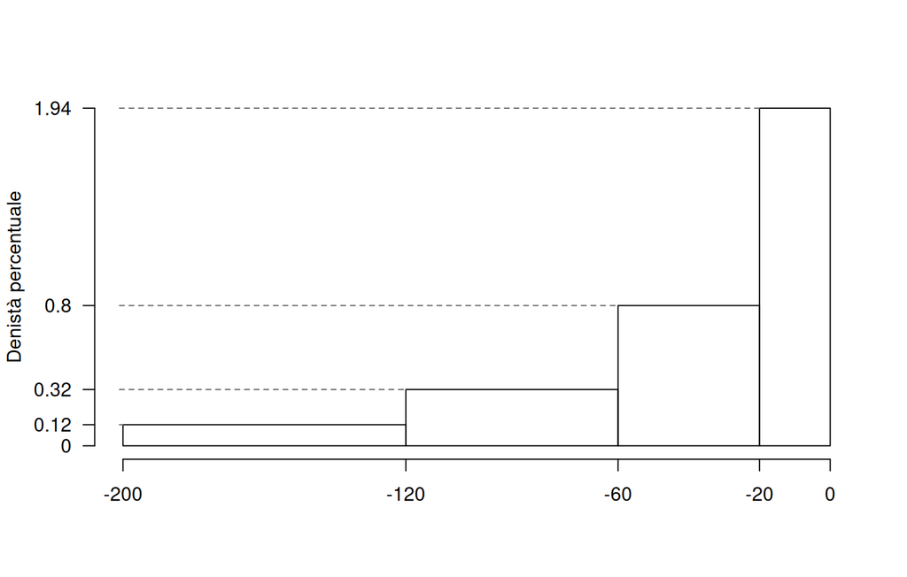

1.b **(pt 0.9/31)** Quante aziende sono maggiori della mediana?

Per definizione $\%(X>x_{ 0.5 })= 50 \%$ e $#(X>x_{ 0.5 }) = 160 $

1.c **(pt 0.6/31)** Osservando l’istogramma, quale relazione possiamo attenderci tra media, moda e mediana?

1.d **(pt 0.6/31)** La perdita media è di $-49.4$ mila euro, mentre la standard deviation è pari $46.6$ mila euro, se lo stato avesse dato un contributo di 50 mila euro, come sarebbero cambiate media e standard deviation?

La SD invariata, la media $-49.4418+50=0.5582$ mila euro.

### Esercizio 2

Due sportelli automatici di una banca rurale vengono monitorati separatamente nella fascia oraria dalle 7:00 alle 8:00 nei giorni feriali. Il numero di operazioni effettuate in quell’ora dallo sportello $A$ segue una distribuzione di Poisson con parametro $2.1$, $X_A \sim \text{Pois}(2.1)$, mentre per lo sportello $B$ vale $X_B \sim \text{Pois}(1.3)$. Le due variabili $X_A$ e $X_B$ sono indipendenti.

2.a **(pt 4.1/31)** Calcolare la probabilità che il numero totale di operazioni tra le 7:00 e le 8:00 $X_A + X_B$ sia compreso tra uno e tre ($P(1\le X_A + X_B\le 3)$)

$$\begin{eqnarray*}
P(1\leq X_A+X_B \leq 3 ) &=& \frac{ 3.4 ^{ 1 }}{ 1 !}e^{- 3.4
}+\frac{ 3.4 ^{ 2 }}{ 2 !}e^{- 3.4 }+\frac{ 3.4 ^{ 3 }}{ 3 !}e^{- 3.4 }
\\
&=& 0.1135+0.1929+0.2186 \\
&=& 0.525
\end{eqnarray*}$$

2.b **(pt 0.9/31)** Calcolare la probabilità che $X_A + X_B= 2$ per 4 settimane consecutive

2.c **(pt 0.6/31)** Sia $Z\sim N(0,1)$ e $Y\sim \chi^2_5$, $Z$ e $Y$ indipendenti. Come si distribuisce
$$\frac{Z}{\sqrt{Y/5}}\sim~~~?$$

Poiché $Z \sim N(0,1)$, $Y \sim \chi^2_5$ e sono indipendenti, allora
$$\frac{Z}{\sqrt{Y/5}}\sim t_5$$

2.d **(pt 0.6/31)** Sia $X$ una VC e siano $A=\{X> 1\}$ e $B=\{X \le 2\}$. Sapendo che $P(A)=0.9$ e $P(B)=0.9$, calcolare $P( A| B)$. (suggerimento: individuare $A$ e $B$ sulla retta reale)

$$\begin{eqnarray*}
P(A|B) &=& \frac{P(A\cap B)}{P(B)}\\
&=& \frac{P(\{X> 1\}\cap\{X \le 2\})}{P(B)}\\
&=& \frac{P(1 < X \le 2)}{0.9}\\
&=& \frac{0.8}{0.9}=0.8889\\
\end{eqnarray*}$$
In quanto
$$\begin{eqnarray*}
P(1 < X \le 2) &=& P(X \le 2) - P(X\le 1)\\
&=& 0.9-0.1\\
&=& 0.8
\end{eqnarray*}$$

Graficamente: se la coda di sinistra ha probabilità 0.1 e quella di destra probabilità 0.1 al centro resta lo 0.8.

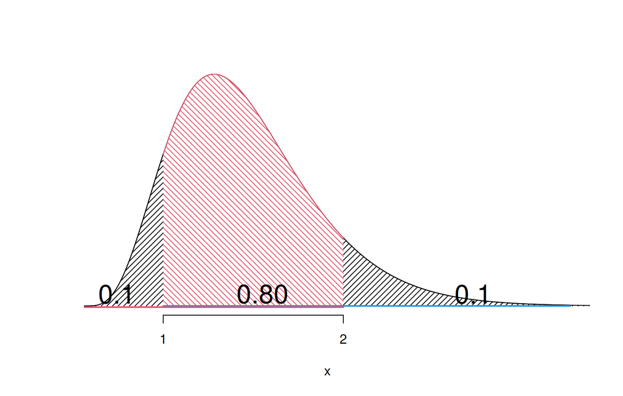

### Esercizio 3

3.a **(pt 4.1/31)** Vengono lanciate due monete perfette, si vince se escono due croci e si perde altrimenti. Si gioca 100 volte, qual è la probabilità vincere più di 20 volte?

$$\pi = \frac 12 \cdot \frac 12 ~~~\text{probabilità di avere due teste in
due estrazioni}$$

**Teorema del Limite Centrale (somma di Bernoulli)**

Siano $X_1$,…,$X_n$, $n=100$ VC IID, tc $X_i\sim\text{Ber}(\pi=0.25)$$,\forall i$, posto:
$$S_n = X_1 + ... + X_n$$
allora:
$$\begin{eqnarray*}
S_n & \mathop{\sim}\limits_{a}& N(n\pi,n\pi(1-\pi)) \\
&\sim & N(100\cdot0.25,100\cdot0.25\cdot(1-0.25)) \\
&\sim & N(25,18.75)
\end{eqnarray*}$$
$$\begin{eqnarray*}
P( S_n > 20 )
&=& P\left( \frac { S_n - n\pi }{ \sqrt{n\pi(1-\pi)}
} > \frac { 20 - 25 }{\sqrt{ 18.75 }} \right) \\
&=& P\left( Z > -1.15 \right)
\\ &=& 1-P(Z< -1.15 )\\
&=& 1-(1-\Phi( 1.15 )) \\ &=& 0.8749
\end{eqnarray*}$$

### Esercizio 4

4.a **(pt 0.9/31)** Sia $\hat\lambda$ lo stimatore di massima verosimiglianza di $\lambda$ del modello di Poisson:
$$\hat\lambda = \frac 1n\sum_{i=1}^n x_i$$
Scrivere la distribuzione asintotica di $\hat\lambda$.

4.b **(pt 0.9/31)** Siano $\hat\theta_1$ e $\hat\theta_2$ due stimatori per $\theta$, cosa significa dire che $\hat\theta_1$ è più efficiente di $\theta_2$?

4.c **(pt 0.9/31)** Definire gli errori di primo e secondo tipo di un test statistico e le relative probabilità.

4.d **(pt 0.9/31)** Se un t-test bilaterale con 13 gradi libertà presenta una t osservata pari a $t_\text{obs}=1.974$, il $p_\text{value}$ sarà maggiore o minore di 0.05? Perché?

Essendo $1.974< 2.1604$, allora $p_\text{value}>0.05$

### Esercizio 5

Nel comune $A$ si è condotta un’intervista per conoscere l’opinione dei cittadini sulla presenza di un ripetitore 5g. Sono state intervistate 26 persone a cui è stato chiesto di esprimete l’opinione in una scala da zero a 100. È risultato un punteggio medio pari a $\hat\mu_A=72.1$ con una standard deviation $\hat\sigma_A=3.4$

5.a **(pt 1.2/31)** Costruire un intervallo di confidenza al 95% per la media di popolazione.

$1-\alpha =0.95$ e quindi $\alpha=0.05\rightarrow \alpha/2=0.025$

$$S =\sqrt{\frac {n}{n-1}}\cdot\hat\sigma =
\sqrt{\frac { 26 }{ 25 }}\cdot 3.4 = 3.4673$$
$$\begin{eqnarray*}
Idc: & & \hat\mu \pm t_{n-1;\alpha/2} \times
\frac{S}{\sqrt{n}} \\
& & 72.1 \pm 2.06 \times \frac{ 3.4673 }{\sqrt{ 26 }} \\
& & 72.1 \pm 2.06 \times 0.68 \\
& & [ 70.7 , 73.5 ]
\end{eqnarray*}$$

5.b **(pt 3.0/31)** Nel comune $B$ si è condotta un’intervista analoga. Sono state intervistate 21 persone si è osservata una media pari $\mu_B=69.6$ e una deviazione standard $\hat\sigma_B=3.3$. Sotto ipotesi di omogeneità testare l’ipotesi che le medie dei due comuni siano uguali contro l’alternativa che siano diverse, per $\alpha=0.1,0.05,0.01,0.001$ e dare una valutazione approssimativa del $p_\text{value}$ (ad esempio il $p_\text{value}$ è minore di 0.001, compreso tra 0.05 e tra 0.01, ecc.).

**Test $T$ per due medie, (omogeneità)**

$\fbox{A}$ FORMULAZIONE DELLE IPOTESI

$$\begin{cases}
H_0: \mu_\text{A} = \mu_\text{B} \\
H_1: \mu_\text{A} \neq \mu_\text{B}
\end{cases}$$

$\fbox{B}$ SCELTA E CALCOLO STATISTICA-TEST, $T$

L’ipotesi è di omogeneità e quindi calcoliamo:
$$S_p^2=\frac{n_\text{ A }\hat\sigma^2_\text{ A }+n_\text{ B
}\hat\sigma^2_\text{ B }}{n_\text{ A }+n_\text{ B }-2} =
\frac{ 26 \cdot 3.4 ^2+ 21 \cdot 3.3 ^2}{ 26 + 21 -2}= 11.76$$

$$\begin{eqnarray*}
\frac{\hat\mu_\text{ A } - \hat\mu_\text{ B }}
{\sqrt{\frac {S^2_p}{n_\text{ A }}+\frac {S^2_p}{n_\text{ B
}}}}&\sim&t_{n_\text{ A }+n_\text{ B }-2}\\
t_{\text{obs}}
&=& \frac{ ( 72.1 - 69.6 )} {\sqrt{\frac{ 11.76 }{ 26
}+\frac{ 11.76 }{ 21 }}}
= 2.485 \, .
\end{eqnarray*}$$

$\fbox{C}$ CONCLUSIONE

Siccome $H_1$ è bilaterale, considereremo $\alpha/2$, anziché $\alpha$

$\alpha=0.1, 0.05, 0.01, 0.001$ e quindi $\alpha/2=0.05, 0.025, 0.005, 0.0005$

I valori critici sono

$t_{47-2;0.05}=1.6794$; $t_{47-2;0.025}=2.0141$; $t_{47-2;0.005}=2.6896$; $t_{47-2;0.0005}=3.5203$

Siccome $2.0141<|t_\text{obs}|=2.4846<2.6896$, quindi **rifiuto** $H_0$ al 5%,

$0.01<p_\text{value}<0.05$, *significativo* $\fbox{*}$.

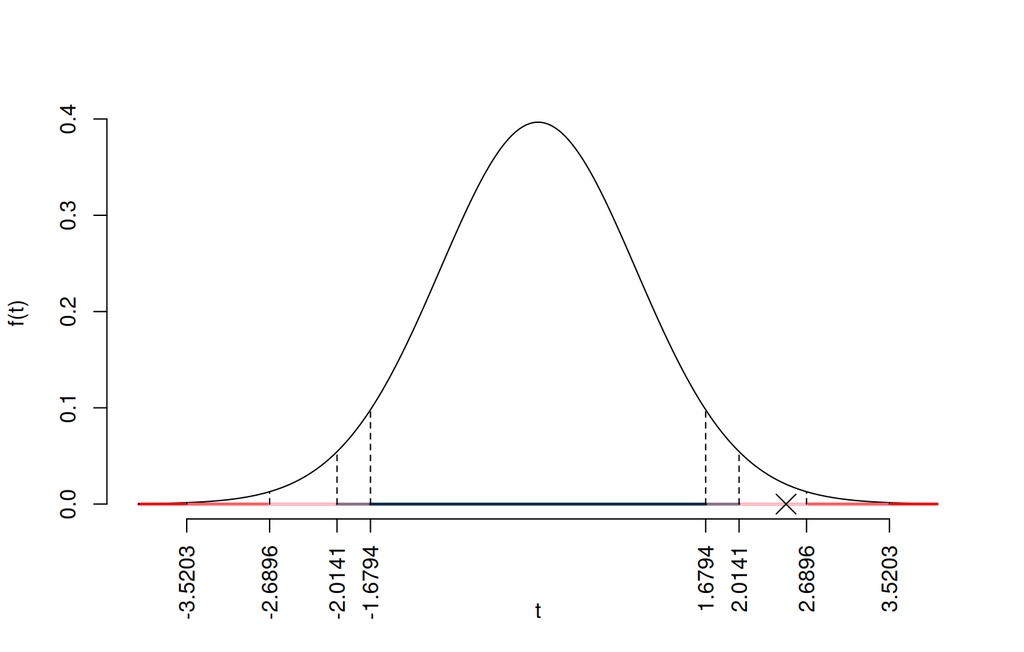

Il $p_{\text{value}}$ è

$$p_{\text{value}} =
P(|T_{47-2}|>|2.48|)=2P(T_{47-2}>2.48)=0.016755$$

Attenzione il calcolo del $p_\text{value}$ con la $T$ è puramente illustrativo e non può essere riprodotto senza una calcolatrice statistica adeguata.
$$0.01 < p_\text{value}= 0.016755 \leq 0.05$$

### Esercizio 6

In uno studio sul reddito, in un campione di $n=50$ individui, sono stati analizzati il livello di istruzione $X$ (in anni di studio) e il reddito annuo $Y$ espresso in migliaia di euro.

Si osservano le seguenti statistiche: $\sum_{i=1}^{50}x_i=708$, $\sum_{i=1}^{50}y_i=449$, $\sum_{i=1}^{50}x_i^2=10786$, $\sum_{i=1}^{50}y_i^2=6091$ e $\sum_{i=1}^{50}x_iy_i=7577$.

6.a **(pt 4.1/31)** Si è osservato $x_3=10$ e $y_3=1.896$, stimare il modello di regressione dove $Y$ viene spiegata da $X$ e calcolare il residuo per il punto $i=3$.

$$\begin{eqnarray*}
\bar x &=&\frac 1 n\sum_{i=1}^n x_i = \frac {1}{ 50
} 708 = 14.16 \\
\bar y &=&\frac 1 n\sum_{i=1}^n y_i = \frac {1}{ 50
} 449 = 8.98 \\
\hat\sigma_X^2&=&\frac 1 n\sum_{i=1}^n x_i^2-\bar
x^2=\frac {1}{ 50 } 10786 - 14.16 ^2= 15.21 \\
\hat\sigma_Y^2&=&\frac 1 n\sum_{i=1}^n y_i^2-\bar
y^2=\frac {1}{ 50 } 6091 - 8.98 ^2= 41.18 \\
\text{cov}(X,Y)&=&\frac 1 n\sum_{i=1}^n x_i~y_i-\bar
x\bar y=\frac {1}{ 50 } 7577 - 14.16 \cdot 8.98 = 24.39 \\
\hat\beta_1 &=&
\frac{\text{cov}(X,Y)}{\hat\sigma_X^2} \\
&=& \frac{ 24.39 }{ 15.21 } = 1.603 \\
\hat\beta_0 &=& \bar y - \hat\beta_1 \bar x\\
&=& 8.98 - 1.603 \times 14.16 = -13.72
\end{eqnarray*}$$
$$\begin{eqnarray*}
\hat y_i &=&\hat\beta_0+\hat\beta_1 x_i=\\
&=& -13.72 + 1.603 \times 10 = 2.311 \\
\hat \varepsilon_i &=& y_i-\hat y_i\\
&=& 1.896 - 2.311 = -0.4154
\end{eqnarray*}$$

6.b **(pt 0.9/31)** Dare un’interpretazione dei parametri di regressione stimati.

6.c **(pt 0.6/31)** Interpretare il diagramma dei residui.

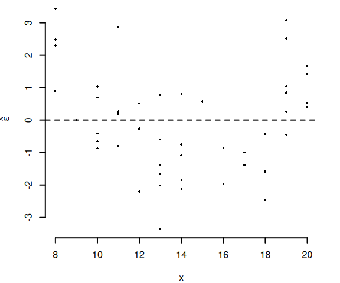

6.d **(pt 0.6/31)** Se in un modello di regressione $r=0$ esclude ogni relazione tra $X$ ed $Y$?

6.e **(pt 0.6/31)** Se in un modello di regressione $r=0.4$, $\hat\sigma_Y=0.8$ e $\hat\beta_1=1$, quanto varrà $\hat\sigma_X$, la standard deviation di $X$?

# Prova di Statistica (CLEAM)

### Esercizio 1

Sono stati registrati i volumi d’affari (in migliaia di euro) di $n = 320$ aziende manifatturiere della provincia di Parma, relativi all’anno 2022. La distribuzione delle frequenze assolute è riportata nella tabella seguente:

| $[\text{x}_j,$ | $\text{x}_{j+1})$ | $n_j$ |
| --- | --- | --- |
| 0 | 20 | 124 |
| 20 | 60 | 103 |
| 60 | 120 | 62 |
| 120 | 200 | 31 |
|  |  | 320 |

1.a **(pt 4.1/31)** Disegnare l’istogramma della densità percentuale delle perdite.

| $[\text{x}_j,$ | $\text{x}_{j+1})$ | $n_j$ | $f_j$ | $b_j$ | $h_j$ | $F_j$ | $\bar{\text{x}}_j$ | $\bar{\text{x}}_j^2$ | $\bar{\text{x}}_jn_j$ | $\bar{\text{x}}_j^2 n_j$ | $f_{j\%}$ |
| --- | --- | --- | --- | --- | --- | --- | --- | --- | --- | --- | --- |
| 0 | 20 | 124 | 0.3875 | 20 | 1.9375 | 0.3875 | 10 | 100 | 1240 | 12400 | 38.750 |
| 20 | 60 | 103 | 0.3219 | 40 | 0.8047 | 0.7094 | 40 | 1600 | 4120 | 164800 | 32.188 |
| 60 | 120 | 62 | 0.1938 | 60 | 0.3229 | 0.9031 | 90 | 8100 | 5580 | 502200 | 19.375 |
| 120 | 200 | 31 | 0.0969 | 80 | 0.1211 | 1.0000 | 160 | 25600 | 4960 | 793600 | 9.688 |
|  |  | 320 | 1.0000 | 200 |  |  |  |  | 15900 | 1473000 | 100.000 |

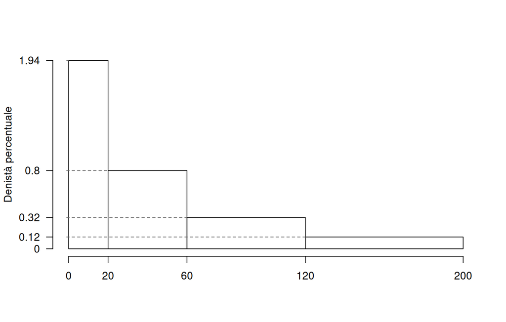

1.b **(pt 0.9/31)** Quante aziende sono maggiori della mediana?

Per definizione $\%(X>x_{ 0.5 })= 50 \%$ e $#(X>x_{ 0.5 }) = 160 $

1.c **(pt 0.6/31)** Osservando l’istogramma, quale relazione possiamo attenderci tra media, moda e mediana?

1.d **(pt 0.6/31)** La perdita media è di $49.5$ mila euro, mentre la standard deviation è pari $47.5$ mila euro, se lo stato avesse dato un contributo di 50 mila euro, come sarebbero cambiate media e standard deviation?

La SD invariata, la media $49.4664+50=99.4664$ mila euro.

### Esercizio 2

Un esperimento clinico ha mostrato che un nuovo farmaco provoca un effetto collaterale lieve nei pazienti con probabilità $\pi = 0.1$. Si trattano $n = 8$ nuovi pazienti.

2.a **(pt 4.1/31)** Qual è la probabilità che al massimo due pazienti manifestino l’effetto collaterale?

$$\begin{eqnarray*}
P( X \leq 2 ) &=& \binom{ 8 }{ 0 } 0.1 ^{ 0 }(1- 0.1 )^{ 8
- 0 }+\binom{ 8 }{ 1 } 0.1 ^{ 1 }(1- 0.1 )^{ 8 - 1 }+\binom{ 8 }{ 2 }
0.1 ^{ 2 }(1- 0.1 )^{ 8 - 2 } \\ &=&
0.4305+0.3826+0.1488 \\ &=& 0.9619
\end{eqnarray*}$$

2.b **(pt 0.9/31)** Sia $X$ la VC del punto precedente e sia $Y\sim N(0,1)$, $X$ ed $Y$ indipendenti. Considerato $A=\{X\leq 2\}$, $B=\{Y<0\}$, calcolare $P(A\cap B)$.

2.c **(pt 0.6/31)** Siano $X$ e $Y$, $X$ e $Y$ indipendenti, tali che $\mu_X=E(X)$, $\sigma_X^2=V(X)$, $\mu_Y=E(Y)$, e $\sigma_Y^2=V(Y)$. Posto $W=2X-Y$, ricavare $E(W)$ e $V(W)$.

$$\begin{eqnarray*}
E(W) &=& 2E(X) - E(Y)\\
&=& 2\mu_X - \mu_Y\\
V(W) &=& (2)^2V(X)+(-1)^2V(Y)\\
&=& 4\sigma_X^2 + \sigma_Y^2
\end{eqnarray*}$$

2.d **(pt 0.6/31)** Sia $X$ una VC e siano $A=\{X\le 1\}$ e $B=\{X \le 2\}$. Sapendo che $P(A)=0.1$ e $P(B)=0.9$, calcolare $P( A| B)$. (suggerimento: individuare $A$ e $B$ sulla retta reale)

$$\begin{eqnarray*}
P(A|B) &=& \frac{P(A\cap B)}{P(B)}\\
&=& \frac{P(\{X\le 1\}\cap\{X \le 2\})}{P(B)}\\
&=& \frac{P(X \le 1)}{0.9}\\
&=& \frac{0.1}{0.9}=0.1111\\
\end{eqnarray*}$$

### Esercizio 3

3.a **(pt 4.1/31)** Un’urna contiene 3 palline col numero $-1$, 4 palline col numero $0$ e 3 palline col numero $+1$. Si estrae con reintroduzione $n=100$ volte, calcolare la probabilità che la somma delle 100 estrazioni sia maggiore di $-7$.

$$\begin{eqnarray*} \mu &=& E(X_i)
= \sum_{x\in S_X}x P(X=x)\\
&=& ( -1 ) \frac { 3 }{ 10 }+ 0 \frac { 4 }{ 10 }+ 1 \frac { 3
}{ 10 } \\
&=& 0 \\
\sigma^2 &=& V(X_i) = \sum_{x\in S_X}x^2 P(X=x)-\mu^2\\
&=&\left( ( -1 ) ^2\frac { 3 }{ 10 }+ 0 ^2\frac { 4 }{ 10 }+
1 ^2\frac { 3 }{ 10 } \right)-( 0 )^2\\
&=& 0.6
\end{eqnarray*}$$
**Teorema del Limite Centrale (somma VC qualunque)**

Siano $X_1$,…,$X_n$, $n=100$ VC IID, tc $E(X_i)=\mu=0$ e $V(X_i)=\sigma^2=0.6,\forall i$, posto:
$$S_n = X_1 + ... + X_n$$
allora:
$$\begin{eqnarray*}
S_n & \mathop{\sim}\limits_{a}& N(n\mu,n\sigma^2) \\
&\sim & N(100\cdot0,100\cdot0.6) \\
&\sim & N(0,60)
\end{eqnarray*}$$
$$\begin{eqnarray*}
P( S_n > -7 )
&=& P\left( \frac { S_n - n\mu }{ \sqrt{n\sigma^2}
} > \frac { -7 - 0 }{\sqrt{ 60 }} \right) \\
&=& P\left( Z > -0.9 \right)
\\ &=& 1-P(Z< -0.9 )\\
&=& 1-(1-\Phi( 0.9 )) \\ &=& 0.8159
\end{eqnarray*}$$

### Esercizio 4

4.a **(pt 0.9/31)** Sia $\hat \pi$ lo stimatore di massima verosimiglianza di $\pi$ del modello di Bernoulli:
$$\hat\pi = \frac 1n\sum_{i=1}^n x_i$$
Scrivere la distribuzione asintotica di $\hat \pi$.

4.b **(pt 0.9/31)** Sia $\hat\theta$ uno stimatore per $\theta$, cosa significa dire che $\hat\theta$ è corretto?

4.c **(pt 0.9/31)** Definire la significatività e la potenza di un test.

4.d **(pt 0.9/31)** Se un t-test bilaterale con 15 gradi libertà presenta una t osservata pari a $t_\text{obs}=3.0236$, il $p_\text{value}$ sarà maggiore o minore di 0.01? Perché?

Essendo $3.0236> 2.9467$, allora $p_\text{value}<0.01$

### Esercizio 5

In uno studio sulla fiducia nei media, in un campione di $n=60$ individui, sono state rilevate due variabili: $X$, che rappresenta il numero di ore settimanali trascorse online (ad esempio su social network, blog, forum), e $Y$, che misura la fiducia nei media mainstream, espressa su una scala da 0 a 10 e opportunamente normalizzata.

Si osservano le seguenti statistiche: $\sum_{i=1}^{60}x_i=749$, $\sum_{i=1}^{60}y_i=314$, $\sum_{i=1}^{60}x_i^2=10265$, $\sum_{i=1}^{60}y_i^2=1930$ e $\sum_{i=1}^{60}x_iy_i=3606$.

5.a **(pt 4.1/31)** stimare il modello di regressione dove $Y$ viene spiegata da $X$ e prevedere $y$ per $x=9$.

$$\begin{eqnarray*}
\bar x &=&\frac 1 n\sum_{i=1}^n x_i = \frac {1}{ 60
} 749 = 12.48 \\
\bar y &=&\frac 1 n\sum_{i=1}^n y_i = \frac {1}{ 60
} 314 = 5.233 \\
\hat\sigma_X^2&=&\frac 1 n\sum_{i=1}^n x_i^2-\bar
x^2=\frac {1}{ 60 } 10265 - 12.4833 ^2= 15.25 \\
\hat\sigma_Y^2&=&\frac 1 n\sum_{i=1}^n y_i^2-\bar
y^2=\frac {1}{ 60 } 1930 - 5.2333 ^2= 4.779 \\
\text{cov}(X,Y)&=&\frac 1 n\sum_{i=1}^n x_i~y_i-\bar
x\bar y=\frac {1}{ 60 } 3606 - 12.4833 \cdot 5.2333 = -5.231 \\
\hat\beta_1 &=&
\frac{\text{cov}(X,Y)}{\hat\sigma_X^2} \\
&=& \frac{ -5.231 }{ 15.25 } = -0.3431 \\
\hat\beta_0 &=& \bar y - \hat\beta_1 \bar x\\
&=& 5.233 - (-0.3431) \times 12.4833 =
9.516
\end{eqnarray*}$$
$$\hat y_{X=
9 }=\hat\beta_0+\hat\beta_1 x= 9.516 + (-0.3431) \times 9 = 6.428$$

5.b **(pt 0.9/31)** Calcolare $r$ ed $r^2$ e interpretarli.

$$\begin{eqnarray*}
r&=&\frac{\text{cov}(X,Y)}{\sigma_X\sigma_Y}=\frac{ -5.231 }{
3.905 \times 2.186 }= -0.6128 \\
r^2&=& 0.3755 < 0.75
\end{eqnarray*}$$

Il modello **non** si adatta bene ai dati.

Il modello spiega il $37.55\%$ della variabilità totale della $Y$.

5.c **(pt 0.6/31)** Se in un modello di regressione $r=+1$ cosa significa?

5.d **(pt 0.6/31)** In un modello di regressione stimato
$$y_i = \hat\beta_0 + \hat\beta_1 x_i + \hat\varepsilon_i,$$
quanto vale $\sum_{i=1}^n\hat\varepsilon_i$?

5.e **(pt 0.6/31)** Se in un modello di regressione $r=0.5$, $\hat\sigma_X=0.9$ e $\hat\beta_1=1.5$, quanto varrà $\hat\sigma_Y$, la standard deviation di $Y$?

5.f **(pt 4.1/31)** Testare l’ipotesi che $\hat\beta_1$ sia uguale a $-0.2$, contro l’alternativa che sia minore per $\alpha=0.1,0.05,0.01,0.001$ e dare una valutazione approssimativa del $p_\text{value}$ (ad esempio il $p_\text{value}$ è minore di 0.001, compreso tra 0.05 e tra 0.01, ecc.).

$$\begin{eqnarray*}
\hat{\sigma_\varepsilon}^2&=&(1-r^2)\hat\sigma_Y^2\\
&=& (1- 0.3755 )\times 4.779 \\
&=& 2.984 \\
S_\varepsilon^2 &=& \frac{n} {n-2}
\hat{\sigma_\varepsilon}^2\\
&=& \frac{ 60 } { 60 -2} \hat{\sigma_\varepsilon}^2 \\
&=& \frac{ 60 } { 60 -2} \times 2.984 = 3.087
\end{eqnarray*}$$

E quindi
$$\begin{eqnarray*}
V(\hat\beta_{1}) &=& \frac{\sigma_{\varepsilon}^{2}} {n
\hat{\sigma}^{2}_{X}} \\
\widehat{V(\hat\beta_{1})} &=& \frac{S_{\varepsilon}^{2}} {n
\hat{\sigma}^{2}_{X}} \\
&=& \frac{ 3.087 } { 60 \times 15.25 } = 0.003374 \\
\widehat{SE(\hat\beta_{1})} &=& \sqrt{ 0.003374 }\\
&=& 0.05809
\end{eqnarray*}$$
$\fbox{A}$ FORMULAZIONE DELLE IPOTESI

$$\begin{cases}
H_0: \beta_1 = \beta_{1;H_0}=-0.2 \\
H_1: \beta_1 < \beta_{1;H_0}=-0.2
\end{cases}$$

$\fbox{B}$ SCELTA E CALCOLO STATISTICA-TEST, $T$ Test su un coefficiente di regressione: $\Rightarrow$ t-Test.

$$\begin{eqnarray*}
\frac{\hat\beta_{ 1 } - \beta_{ 1 ;H_0}} {\widehat{SE(\hat\beta_{ 1
})}}&\sim&t_{n-2}\\
t_{\text{obs}}
&=& \frac{ ( -0.3431 - -0.2 )} { 0.05809 }
= -2.463 \, .
\end{eqnarray*}$$

$\fbox{C}$ CONCLUSIONE

Consideriamo $\alpha=0.1, 0.05, 0.01, 0.001$

I valori critici sono

$t_{60-2;0.1}=-1.2963$; $t_{60-2;0.05}=-1.6716$; $t_{60-2;0.01}=-2.3924$; $t_{60-2;0.001}=-3.2368$

$0.001<p_\text{value}<0.01$, *molto significativo* $\fbox{**}$.

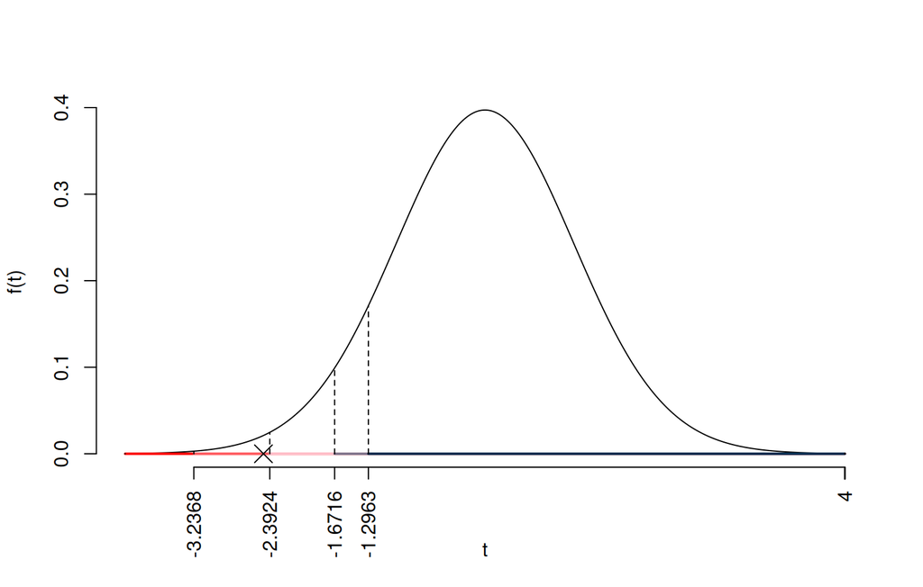

Il $p_{\text{value}}$ è

$$p_{\text{value}} =
P(T_{60-2}<-2.46)=0.008389$$

Attenzione il calcolo del $p_\text{value}$ con la $T$ è puramente illustrativo e non può essere riprodotto senza una calcolatrice statistica adeguata.
$$0.001 < p_\text{value}= 0.008389 \leq 0.01$$

# Prova di Statistica (CLEAM)

### Esercizio 1

Nel comune norvegese di Tromsø, noto per il clima subartico temperato, sono state registrate $n=200$ temperature medie giornaliere casuali nell’arco di un anno. Qui di seguito la distribuzione delle frequenze cumulate (dati espressi in gradi Celsius):

| $[\text{x}_j,$ | $\text{x}_{j+1})$ | $F_j$ |
| --- | --- | --- |
| -15 | -5 | 0.125 |
| -5 | 0 | 0.500 |
| 0 | 5 | 0.875 |
| 5 | 15 | 1.000 |

1.a **(pt 4.1/31)** Disegnare l’istogramma della densità percentuale delle temperature.

| $[\text{x}_j,$ | $\text{x}_{j+1})$ | $n_j$ | $f_j$ | $b_j$ | $h_j$ | $F_j$ | $\bar{\text{x}}_j$ | $\bar{\text{x}}_j^2$ | $\bar{\text{x}}_jn_j$ | $\bar{\text{x}}_j^2 n_j$ | $f_{j\%}$ |
| --- | --- | --- | --- | --- | --- | --- | --- | --- | --- | --- | --- |
| -15 | -5 | 25 | 0.125 | 10 | 1.25 | 0.125 | -10.0 | 100.00 | -250.0 | 2500.0 | 12.5 |
| -5 | 0 | 75 | 0.375 | 5 | 7.50 | 0.500 | -2.5 | 6.25 | -187.5 | 468.8 | 37.5 |
| 0 | 5 | 75 | 0.375 | 5 | 7.50 | 0.875 | 2.5 | 6.25 | 187.5 | 468.8 | 37.5 |
| 5 | 15 | 25 | 0.125 | 10 | 1.25 | 1.000 | 10.0 | 100.00 | 250.0 | 2500.0 | 12.5 |
|  |  | 200 | 1.000 | 30 |  |  |  |  | 0.0 | 5937.5 | 100.0 |

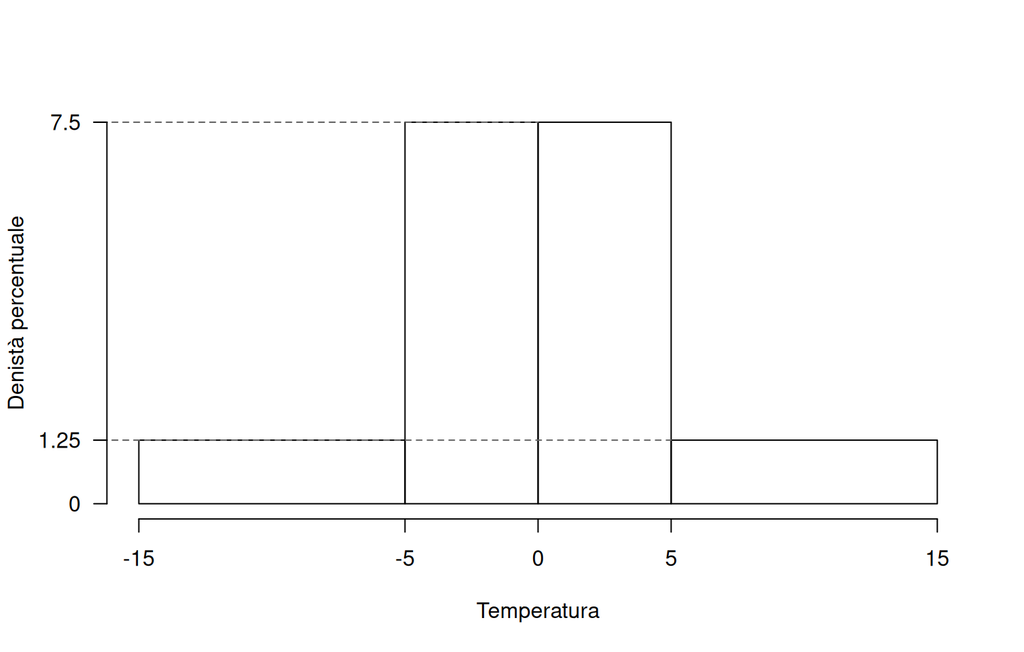

1.b **(pt 0.9/31)** Per quanti giorni le temperature sono state superiori al 25-esimo percentile?

Per definizione $\%(X>x_{ 0.25 })= 75 \%$ e $#(X>x_{ 0.25 }) = 150 $

1.c **(pt 0.6/31)** Osservando l’istogramma, quale relazione possiamo attenderci tra media, moda e mediana?

La distribuzione è simmetrica rispetto a 0 e quindi:
$$\bar x \approx x_{0.5} \approx 0$$

1.d **(pt 0.6/31)** La media e la varianza sono risultati pari a $\bar x = 0$ e $\sigma^2 =30$. Se invece si fossero registrate le stesse temperature in gradi Fahrenheit ($F° = 32 + 1.8 C°$), come cambiano media e varianza?

### Esercizio 2

Sia $X\sim N(1,2)$ e sia $Y\sim N(0,2)$, $X$ e $Y$ indipendenti, sia $A=\{X<0\}$ $B=\{Y<0\}$.

2.a **(pt 4.1/31)** Calcolare $P(A\cup B)$.

$$\begin{eqnarray*}
P( X < 0 )
&=& P\left( \frac { X - \mu }{ \sigma } < \frac
{ 0 - 1 }{\sqrt{ 2 }} \right) \\
&=& P\left( Z < -0.71 \right) \\
&=& 1-\Phi( 0.71 ) \\ &=& 0.2389
\end{eqnarray*}$$
$$\begin{eqnarray*}
P( Y < 0 )
&=& P\left( \frac { Y - \mu }{ \sigma } < \frac
{ 0 - 0 }{\sqrt{ 2 }} \right) \\
&=& P\left( Z < 0 \right) \\
&=& \Phi( 0 ) \\ &=& 0.5
\end{eqnarray*}$$
$$\begin{eqnarray}
P( A \cup B ) &=& P( A )+P( B )-P( A \cap B ) \\
&=& P( A )+P( B )-P( A )\cdot ( B ) \\
&=& 0.2389 + 0.5 - 0.2389 \times
0.5 \\
&=& 0.6194 \end{eqnarray}$$

2.b **(pt 0.9/31)** Un’urna ha una pallina con la lettera $X$ e due palline con la lettera $Y$. Si estrae una volta, se esce la pallina $X$ si estrae $W$ da $W\sim N(1,2)$, se esce la pallina $Y$ si estrae da $W\sim N(0,2)$. Qual è la probabilità che $W<0$?

$$P(W<0)=P(X)P(W<0|X)+P(Y)P(W<0|Y)= \frac 13 \cdot0.2389+\frac 23
\cdot 0.5=0.413$$

2.c **(pt 0.6/31)** Siano $X$ e $Y$, $X$ e $Y$ indipendenti, tali che $E(X)=1$, $V(X)=1$, $E(Y)=3.2$, e $V(Y)=0.1$. Posto $W=aX+bY$, ricavare $E(W)$ e $V(W)$.

2.d **(pt 0.6/31)** Sia $X\sim\text{Binom}(n=2,\pi=0.3)$, disegnare $F(x)$, la funzione di ripartizione di $X$, per $x$ che varia nell’intervallo nell’intervallo $-1<x<1.5$.

### Esercizio 3

3.a **(pt 4.1/31)** Un’urna contiene 3 palline Rosse, 4 Blue e 3 palline Verdi. Si vince se esce Rossa e si perde altrimenti. Si estrae con reintroduzione $n=100$ volte, calcolare la probabilità di vincere più di 25 volte su 100 giocate.

$$\pi = \frac 3{10}=0.3$$
**Teorema del Limite Centrale (somma di Bernoulli)**

Siano $X_1$,…,$X_n$, $n=100$ VC IID, tc $X_i\sim\text{Ber}(\pi=0.3)$$,\forall i$, posto:
$$S_n = X_1 + ... + X_n$$
allora:
$$\begin{eqnarray*}
S_n & \mathop{\sim}\limits_{a}& N(n\pi,n\pi(1-\pi)) \\
&\sim & N(100\cdot0.3,100\cdot0.3\cdot(1-0.3)) \\
&\sim & N(30,21)
\end{eqnarray*}$$
$$\begin{eqnarray*}
P( S_n > 25 )
&=& P\left( \frac { S_n - n\pi }{ \sqrt{n\pi(1-\pi)}
} > \frac { 25 - 30 }{\sqrt{ 21 }} \right) \\
&=& P\left( Z > -1.09 \right)
\\ &=& 1-P(Z< -1.09 )\\
&=& 1-(1-\Phi( 1.09 )) \\ &=& 0.8621
\end{eqnarray*}$$

### Esercizio 4

4.a **(pt 0.9/31)** Sia $\hat \mu$ lo stimatore di massima verosimiglianza di $\mu$ del modello Normale:
$$\hat\mu = \frac 1n\sum_{i=1}^n x_i$$
Scrivere la distribuzione di $\hat \mu$.

4.b **(pt 0.9/31)** Si definisce la *precisione* di una misura l’inverso della varianza
$$\tau = \frac 1{\sigma^2}.$$
Posto con $\hat\sigma^2$ la stima di massima verosimiglianza di $\sigma^2$, in virtù di quale proprietà è lecito stimare $\hat\tau$ con
$$\hat\tau = \frac 1{\hat\sigma^2}~~~~?$$

4.c **(pt 0.9/31)** Disegnare la tavola della verità di un test, scrivendo nel riquadro appropriato: gli errori di primo, gli errori di secondo tipo, la significatività, e la potenza del test.

4.d **(pt 0.9/31)** Se un t-test bilaterale con 19 gradi libertà presenta una t osservata pari a $t_\text{obs}=5.974$, il $p_\text{value}$ sarà maggiore o minore di 0.001? Perché?

Essendo $5.974> 3.8834$, allora $p_\text{value}<0.001$

### Esercizio 5

Nel comune $A$ si è condotta un’intervista per conoscere l’opinione dei cittadini sulla presenza di un ripetitore 5G. Sono state intervistate 130 persone e 91 hanno dichiarato di essere favorevoli.

5.a **(pt 1.2/31)** Costruire un intervallo di confidenza al 95% per la proporzione $\pi_A$ di cittadini favorevoli nel comune $A$.

$1-\alpha =0.95$ e quindi $\alpha=0.05\rightarrow \alpha/2=0.025$

$$\hat\pi = \frac{S_n}n = \frac{ 91 }{ 130 }= 0.7$$

$$\begin{eqnarray*}
Idc: & & \hat\pi \pm z_{\alpha/2} \times
\sqrt{\frac{\hat\pi(1-\hat\pi)}{n}} \\
& & 0.7 \pm 1.96 \times \sqrt{\frac{ 0.7 (1- 0.7 )}{ 130
}} \\
& & 0.7 \pm 1.96 \times 0.04019 \\
& & [ 0.6212 , 0.7788 ]
\end{eqnarray*}$$

5.b **(pt 3.0/31)** Nel comune $B$ è stata condotta la stessa indagine: su 120 persone intervistate, 74 si sono dette favorevoli. Testare l’ipotesi che la proporzione di cittadini favorevoli sia uguale nei due comuni, contro l’alternativa che sia diversa. Risolvere con il $p_\text{value}$ e confrontarlo per $\alpha = 0.1,\ 0.05,\ 0.01,\ 0.001$.

**Test $Z$ per due proporzioni**

$\fbox{A}$ FORMULAZIONE DELLE IPOTESI

$$\begin{cases}
H_0: \pi_\text{A} = \pi_\text{B} \\
H_1: \pi_\text{A} \neq \pi_\text{B}
\end{cases}$$

$\fbox{B}$ SCELTA E CALCOLO STATISTICA-TEST, $Z$

$$\hat\pi_\text{ A }=\frac{s_\text{ A
}}{n_\text{ A }}=\frac{ 91 }{ 130 }= 0.7 \qquad
\hat\pi_\text{ B }=\frac{s_\text{ B }}{n_\text{ B }}=\frac{ 74 }{ 120
}= 0.6167$$
Calcoliamo la proporzione comune sotto $H_0$
$$\pi_C=\frac{s_\text{ A }+s_\text{ B }}{n_\text{ A }+n_\text{ B }}=
\frac{ 165 }{ 250 }= 0.66$$
$$\begin{eqnarray*}
\frac{\hat\pi_\text{ A } - \hat\pi_\text{ B }}
{\sqrt{\frac {\pi_C(1-\pi_C)}{n_\text{ A }}+\frac
{\pi_C(1-\pi_C)}{n_\text{ B }}}}&\sim&N(0,1)\\
z_{\text{obs}}
&=& \frac{ ( 0.7 - 0.6167 )} {\sqrt{\frac{ 0.66 (1- 0.66 )}{
130 }+\frac{ 0.66 (1- 0.66 )}{ 120 }}}
= 1.39 \, .
\end{eqnarray*}$$

$\fbox{C}$ CONCLUSIONE

Il $p_{\text{value}}$ è

$$p_{\text{value}} =
P(|Z|>|1.39|)=2P(Z>1.39)=0.164641$$

$$0.1 < p_\text{value}= 0.164641 \leq 1$$

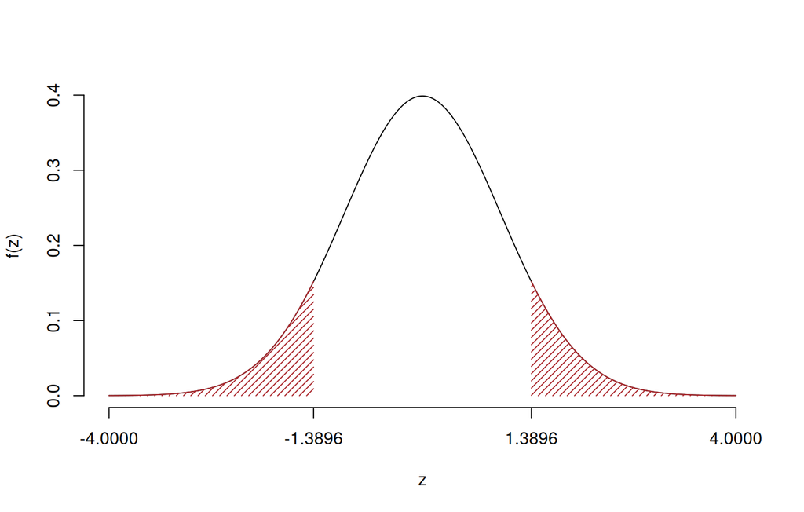

**Non** rifiuto $H_0$ a **nessun** livello di significatività,

$p_\text{value}>0.1$, *non significativo*

### Esercizio 6

In uno studio sui fattori che influenzano la salute, è stato analizzato un campione di $n = 50$ individui. Per ciascuno sono state registrate le ore settimanali dedicate all’attività fisica $X$ (es. camminata, corsa, palestra), e l’indice di massa corporea $Y$ (BMI), ricondotto su scala numerica tra 20 e 30.

Sono state calcolate le seguenti statistiche:

$$\sum_{i=1}^{50} x_i = 222, \qquad \sum_{i=1}^{50} y_i = 1286, \\
\sum_{i=1}^{50} x_i^2 = 1448, \qquad \sum_{i=1}^{50} y_i^2 = 33495, \\
\sum_{i=1}^{50} x_i y_i = 5296.$$

6.a **(pt 4.1/31)** stimare il modello di regressione dove $Y$ viene spiegata da $X$ e prevedere $y$ per $x=9.7$

$$\begin{eqnarray*}
\bar x &=&\frac 1 n\sum_{i=1}^n x_i = \frac {1}{ 50
} 222 = 4.44 \\
\bar y &=&\frac 1 n\sum_{i=1}^n y_i = \frac {1}{ 50
} 1286 = 25.72 \\
\hat\sigma_X^2&=&\frac 1 n\sum_{i=1}^n x_i^2-\bar
x^2=\frac {1}{ 50 } 1448 - 4.44 ^2= 9.246 \\
\hat\sigma_Y^2&=&\frac 1 n\sum_{i=1}^n y_i^2-\bar
y^2=\frac {1}{ 50 } 33495 - 25.72 ^2= 8.382 \\
\text{cov}(X,Y)&=&\frac 1 n\sum_{i=1}^n x_i~y_i-\bar
x\bar y=\frac {1}{ 50 } 5296 - 4.44 \cdot 25.72 = -8.277 \\
\hat\beta_1 &=&
\frac{\text{cov}(X,Y)}{\hat\sigma_X^2} \\
&=& \frac{ -8.277 }{ 9.246 } = -0.8952 \\
\hat\beta_0 &=& \bar y - \hat\beta_1 \bar x\\
&=& 25.72 - (-0.8952) \times 4.44 = 29.69
\end{eqnarray*}$$
$$\hat y_{X=
9.7 }=\hat\beta_0+\hat\beta_1 x= 29.69 + (-0.8952) \times 9.7 = 21.01$$

6.b **(pt 0.9/31)** Qual è la percentuale di varianza spiegata dal modello?

$$\begin{eqnarray*}
r&=&\frac{\text{cov}(X,Y)}{\sigma_X\sigma_Y}=\frac{ -8.277 }{
3.041 \times 2.895 }= -0.9403 \\
r^2&=& 0.8841\end{eqnarray*}$$

Il modello spiega il $88.41\%$ della variabilità totale della $Y$.

6.c **(pt 0.6/31)** Se in un modello di regressione $r=-1$ cosa significa?

6.d **(pt 0.6/31)** Definire il diagramma dei residui.

6.e **(pt 0.6/31)** Se in un modello di regressione $\hat\sigma_X=0.9$, $\hat\sigma_Y=1.2$ e $\hat\beta_1=-0.8$, quanto varrà $r$, il coefficiente di correlazione tra $X$ ed $Y$?